# RNAseq Arabidopsis thaliana- Różnicowa analiza ekspresji

Paulina Dziwak

# Ładowanie danych i potrzebnych bibliotek

```r
# Import libraries
library("rmdformats")
library("DESeq2")
library("tidyverse")

# import the samples to conditions correspodence
xp_design <- read.delim("dane_cz2/samples_to_conditions.txt",
                        header = T,
                        sep = ",",
                        stringsAsFactors = F,
                        colClasses = rep("character",4))%>%     # read columns as a character strings
  column_to_rownames("sample")
```

Ponieważ nie chcemy pracować nad wszystkimi porównaniami, odfiltrujemy próbki i warunki, których nie potrzebujemy.

```r
xp_design_mock_vs_infected = xp_design %>%
  filter(growth == "MgCl2" & dpi == "7")
```

Teraz przefiltrujemy zarówno obiekty, raw_countsjak i xp_design, aby zachować jednoczynnikowe porównanie i zbadać transkryptom liści roślin Arabidopsis, których nasiona zostały potraktowane MgCl2 i których rośliny zostały zakażone lub nie Pseudomonas syringae DC3000 w 7 dpi (po 7 dniach indukcji).

```r
# Import the gene raw counts
raw_counts <- read.csv("dane_cz2/raw_counts.csv", header = T, stringsAsFactors = F) %>%
  column_to_rownames("Geneid")

# reorder counts columns according to the complete list of samples
raw_counts <- raw_counts[ , row.names(xp_design)]

# Filter count file accordingly (to keep only samples present in the filtered xp_design file)
raw_counts_filtered = raw_counts[, colnames(raw_counts) %in% row.names(xp_design_mock_vs_infected)]

all(colnames(raw_counts_filtered) %in% rownames(xp_design_mock_vs_infected))
```

```
## [1] TRUE
```

```r
all(colnames(raw_counts_filtered) == rownames(xp_design_mock_vs_infected))
```

```
## [1] TRUE
```

Teraz gdy kolumny i wiersze są dopasowane możemy utworzyć objekt DESeqDataSet

```r
## Creation of the DESeqDataSet
dds <- DESeqDataSetFromMatrix(countData = raw_counts_filtered,
                              colData = xp_design_mock_vs_infected,
                              design = ~ infected)
dds
```

```
## class: DESeqDataSet
## dim: 33768 8
## metadata(1): version
## assays(1): counts
## rownames(33768): AT1G01010 AT1G01020 ... ATMG01400 ATMG01410
## rowData names(0):
## colnames(8): ERR1406305 ERR1406306 ... ERR1406265 ERR1406266
## colData names(3): growth infected dpi
```

Domyślnie R wybierze poziom odniesienia dla czynników na podstawie porządku alfabetycznego. Wtedy, jeśli nigdy nie powiesz funkcjom DESeq2, z którym poziomem chcesz porównać (np. który poziom reprezentuje grupę kontrolną), porównania będą oparte na kolejności alfabetycznej poziomów. Można to rozwiązać w ten sposób, aczkolwiek u nas jest poprawnie.

```r
dds$infected
```

```
## [1] mock                        mock
## [3] mock                        mock
## [5] Pseudomonas_syringae_DC3000 Pseudomonas_syringae_DC3000
## [7] Pseudomonas_syringae_DC3000 Pseudomonas_syringae_DC3000
## Levels: mock Pseudomonas_syringae_DC3000
```

```r
#dds$infected <- factor(dds$infected, levels = c("mock","Pseudomonas_syringae_DC3000"))
```

# Przeprowadzenie analizy DE

Przy użyciu funkcji Results, wyodrębiniana jest tabela wyników z log2-krotnymi zmianami, wartościami p i skorygowanymi wartościami p.

```r
dds <- DESeq(dds)
all_genes_results <- results(dds)
head(all_genes_results)
```

```
## log2 fold change (MLE): infected Pseudomonas syringae DC3000 vs mock
## Wald test p-value: infected Pseudomonas syringae DC3000 vs mock
## DataFrame with 6 rows and 6 columns
##            baseMean log2FoldChange     lfcSE      stat      pvalue       padj
##           <numeric>      <numeric> <numeric> <numeric>   <numeric>  <numeric>
## AT1G01010   87.4203      0.3672806  0.211702  1.734897 0.082759060 0.18722371
## AT1G01020  477.1530      0.2663723  0.107898  2.468749 0.013558621 0.04572769
## AT1G03987   14.6179      1.4707140  0.462673  3.178735 0.001479191 0.00740164
## AT1G01030  194.0951      0.9166233  0.276959  3.309597 0.000934304 0.00506641
## AT1G03993  175.9825     -0.1084689  0.142106 -0.763293 0.445288450 0.61400086
## AT1G01040 1761.9499     -0.0519691  0.076330 -0.680848 0.495967753 0.65803411
```

**Interpretacja logarytmu krotności zmiany (log2FoldChange)**  
Dodatnia wartość log2FoldChange wskazuje, że poziom ekspresji genu jest wyższy w grupie leczonej w porównaniu z grupą kontrolną, podczas gdy wartość ujemna wskazuje, że poziom ekspresji jest niższy w grupie leczonej. Wielkość wartości log2FoldChange wskazuje stopień różnicy w poziomach ekspresji genów między dwiema grupami.  
Przykład:  
untreated = 230  
treated = 750  
log2(treated/untreated) # equals 1.705257

U nas:  
log2(Pseudomonas syringae DC3000 / mock)

Dla przykładu, gdy log2FoldChange wynosi 1, oznacza to, że ekspresja danego genu w jednej grupie jest dwukrotnie większa niż w drugiej grupie. Z kolei, gdy log2FoldChange wynosi -1, oznacza to, że ekspresja danego genu w jednej grupie jest dwukrotnie mniejsza niż w drugiej grupie.

```r
mcols(all_genes_results)
```

```
## DataFrame with 6 rows and 2 columns
##                        type            description
##                 <character>            <character>
## baseMean       intermediate mean of normalized c..
## log2FoldChange      results log2 fold change (ML..
## lfcSE               results standard error: infe..
## stat                results Wald statistic: infe..
## pvalue              results Wald test p-value: i..
## padj                results   BH adjusted p-values
```

# P-value i P-value adjusted

**P-value** to wartość określająca prawdopodobieństwo wystąpienia różnic lub zależności między dwiema zmiennymi w próbie badawczej, przy założeniu, że hipoteza zerowa jest prawdziwa. Niskie wartości p-value sugerują, że wyniki badania są znaczące statystycznie, co oznacza, że hipoteza zerowa może zostać odrzucona na rzecz alternatywnej hipotezy badawczej.

P-value nie uwzględnia jednak faktu, że wiele porównań statystycznych może zostać przeprowadzonych w ramach jednego badania, co zwiększa ryzyko popełnienia błędu typu I (fałszywie odrzucenie hipotezy zerowej, gdy jest ona prawdziwa). Aby zminimalizować to ryzyko, można skorygować p-value za pomocą p-value adjust, zwanej również korektą multipleksową.

**P-value adjusted** to wartość p, która uwzględnia liczbę porównań statystycznych przeprowadzonych w badaniu. W wyniku tej korekty, wartość p jest zwykle wyższa niż wartość oryginalnego p-value. Zastosowanie p-value adjusted pozwala na bardziej rygorystyczne określenie, które wyniki badania są statystycznie istotne.

# Fałszywe wskaźniki odkrycia

```r
library(dplyr)

# threshold of p = 0.01
all_genes_results %>%
  as.data.frame() %>%
  filter(padj < 0.01) %>%
  dim()
```

```
## [1] 4979    6
```

```r
# threshold of p = 0.001
all_genes_results %>%
  as.data.frame() %>%
  filter(padj < 0.001) %>%
  dim()
```

```
## [1] 3249    6
```

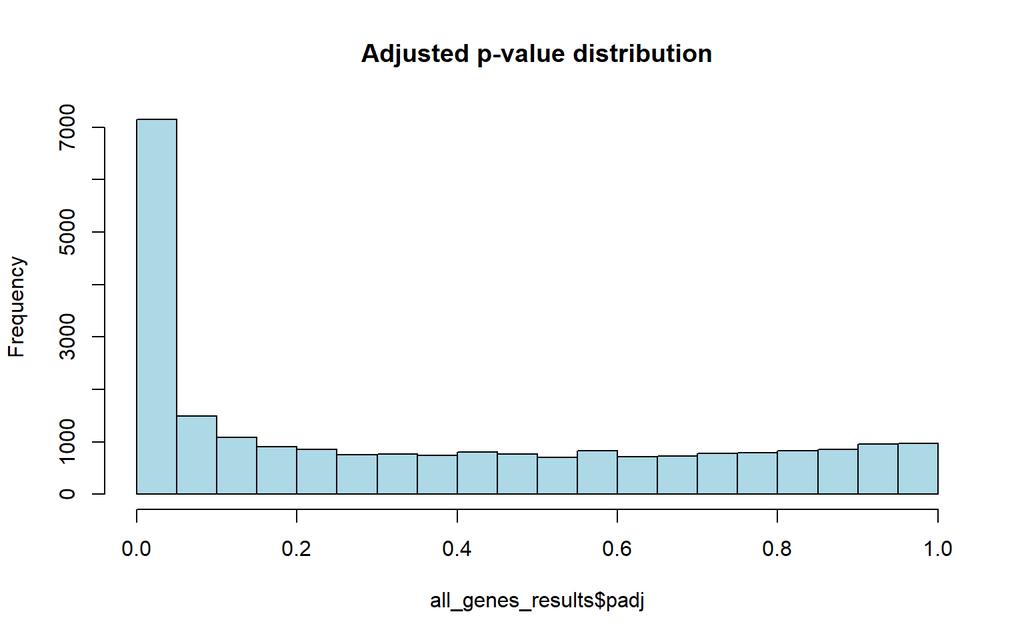

```r
# distribution of adjusted p-values
hist(all_genes_results$padj, col="lightblue", main = "Adjusted p-value distribution")
```

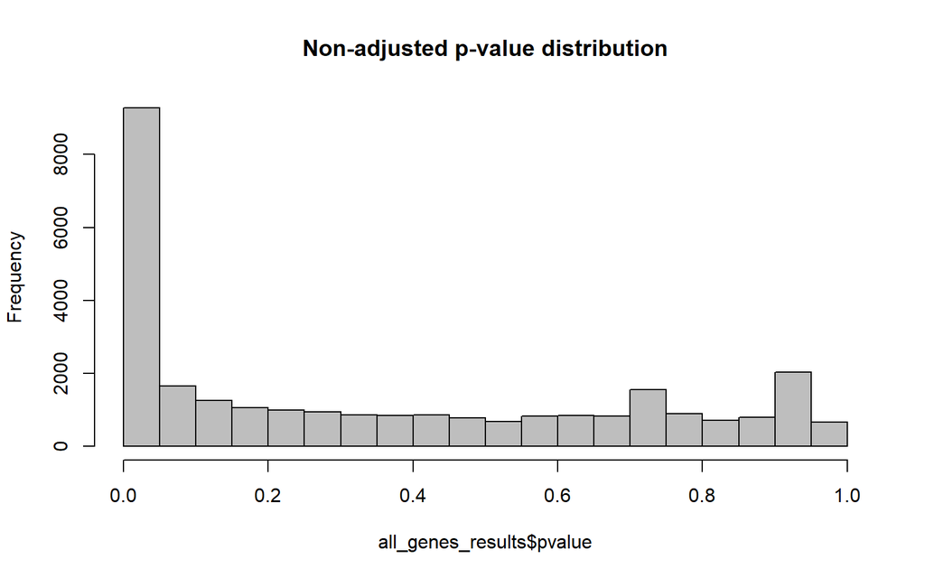

```r
# distribution of non-adjusted p-values
hist(all_genes_results$pvalue, col="grey", main = "Non-adjusted p-value distribution")
```

Rozkład wartości p był już dość podobny, co sugeruje, że znaczna część testów ma znaczącą wartość p.

# Wyodrębnianie tabeli różnicujących genów

```r
diff_genes = all_genes_results %>%
  as.data.frame() %>%
  rownames_to_column("genes") %>%
  filter(padj < 0.01) %>%
  arrange(desc(log2FoldChange),
          desc(padj))
head(diff_genes)
```

```
##       genes    baseMean log2FoldChange     lfcSE      stat       pvalue
## 1 AT4G11911   440.67322      10.011976 0.9492103 10.547690 5.206155e-26
## 2 AT4G21830    54.53419       9.421513 1.7051598  5.525297 3.289295e-08
## 3 AT2G39030 16340.78493       9.260455 0.6720377 13.779666 3.378332e-43
## 4 AT4G15200   784.08131       9.054633 0.7917892 11.435661 2.774167e-30
## 5 AT1G51780  2067.96768       9.034621 1.0461393  8.636156 5.813636e-18
## 6 AT4G10290   800.91998       8.853689 0.8074221 10.965378 5.606548e-28
##           padj
## 1 7.928568e-24
## 2 6.401977e-07
## 3 1.685788e-40
## 4 6.256013e-28
## 5 4.328483e-16
## 6 1.035357e-25
```

```r
#write.csv(diff_genes, file = "geny_roznicujace.txt" )
```

# Wulkanoplot

Kurczymy log2FoldChange aby usunąć szum wynikający z genów z małą ilością zliczeń. Pomaga to uzyskać bardziej znaczące log2FoldChange (LFC) dla wszystkich genów niezależnie od ich poziomu ekspresji.

```r
library("apeglm")

resLFC <- lfcShrink(dds = dds,
                  res = all_genes_results,
                  type = "normal",
                  coef = "infected_Pseudomonas_syringae_DC3000_vs_mock")
```

head(order(resLFC$padj),20) zwraca indeksy 20 genów o najmniejszych wartościach skorygowanych wartości p. Te geny są uważane za najbardziej różnicujące między grupami.

Parametr “dds” to obiekt klasy “DESeqDataSet”, który zawiera informacje o danych sekwencjonowania RNA, takie jak liczba odczytów dla każdego genu w każdej próbce. Parametr “res” zawiera wyniki różnicowej ekspresji dla wszystkich genów, które zostały uzyskane z użyciem funkcji “results” z pakietu “DESeq2”.

Parametr “type” określa metodę zwijania, która ma być użyta. W tym przypadku jest to metoda “normal”. Oznacza to, że zostanie zastosowana metoda zwijania Bayesa z wagami równymi dla każdego genu.

Parametr “coef” określa, który współczynnik regresji ma zostać użyty do porównania między próbkami zainfekowanymi a kontrolnymi. W tym przypadku jest to “infected_Pseudomonas_syringae_DC3000_vs_mock”.

Funkcja “lfcShrink” zwraca wyniki zwiniętej różnicowej ekspresji log2FC dla każdego genu.

Współczynniki (coef) są istotne w analizie DE, ponieważ pozwalają określić, jakie porównanie między grupami lub poziomami zmiennej objaśniającej jest badane pod kątem różnicowej ekspresji. Aby zobaczyć, jakie współczynniki można wyodrębnić:

```r
resultsNames(dds)
```

```
## [1] "Intercept"
## [2] "infected_Pseudomonas_syringae_DC3000_vs_mock"
```

```r
# load the library if not done yet
library("EnhancedVolcano")
```

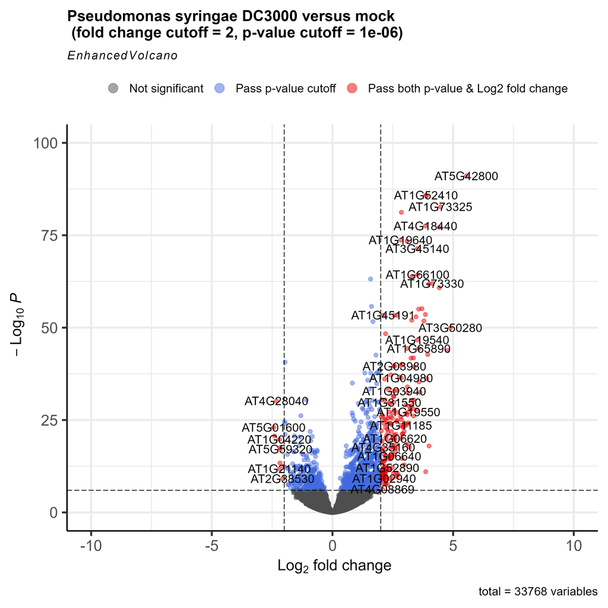

```r
# The main function is named after the package
ev_plot <- EnhancedVolcano(toptable = resLFC,
                x = "log2FoldChange",
                y = "padj",
                lab = rownames(resLFC),
                xlim = c(-10, +10),
                ylim = c(0,100),
                pCutoff = 1e-06,
                FCcutoff = 2,
                title = "Pseudomonas syringae DC3000 versus mock \n (fold change cutoff = 2, p-value cutoff = 1e-06)",
                legendLabels=c('Not significant',
                  'Log2 fold-change (but do not pass p-value cutoff)',
                  'Pass p-value cutoff',
                  'Pass both p-value & Log2 fold change')
                )
#ggsave("wulkano_plot.png", plot = ev_plot, width = 10, height = 10)
```

Wykres wulkanu to rodzaj wykresu rozrzutu, który pokazuje istotność statystyczną (wartość P) w funkcji wielkości zmiany (krotność zmiany). Umożliwia szybką identyfikację wizualną genów z dużymi fałdami zmian, które są również istotne statystycznie. Mogą to być geny o największym znaczeniu biologicznym. Na wykresie wulkanu geny o największej regulacji w górę znajdują się po prawej stronie, geny o największej regulacji w dół po lewej, a najbardziej statystycznie istotne geny są u góry.

# Normalizacja

Najpierw znormalizujemy raw_counts za pomocą niestandardowej funkcji, która naśladuje procedurę normalizacji DESeq2

```r
# import custom function
# copy-paste and execute this code in your console to get the mor_normalization() function

mor_normalization = function(data){
  library(dplyr)
  library(tibble)

  # take the log
  log_data = log(data)

  # find the psuedo-references per sample by taking the geometric mean
  log_data = log_data %>%
               rownames_to_column('gene') %>%
               mutate (gene_averages = rowMeans(log_data)) %>%
               filter(gene_averages != "-Inf")

  # the last columns is the pseudo-reference column
  pseudo_column = ncol(log_data)

  # where to stop before the pseudo column
  before_pseduo = pseudo_column - 1

  # find the ratio of the log data to the pseudo-reference
  ratios = sweep(log_data[,2:before_pseduo], 1, log_data[,pseudo_column], "-")

  # find the median of the ratios
  sample_medians = apply(ratios, 2, median)

  # convert the median to a scaling factor
  scaling_factors = exp(sample_medians)

  # use scaling factors to scale the original data
  manually_normalized = sweep(data, 2, scaling_factors, "/")
  return(manually_normalized)
}
```

```r
scaled_counts <- mor_normalization(raw_counts_filtered)
head(scaled_counts)
```

```
##           ERR1406305  ERR1406306  ERR1406307 ERR1406308 ERR1406263 ERR1406264
## AT1G01010   85.83575   90.910197   69.891325   59.41828   74.15774  114.25728
## AT1G01020  452.20786  456.549010  398.076675  426.22715  511.29812  588.94434
## AT1G03987   13.95703    4.995066    5.064589    6.33795   16.91317   20.77405
## AT1G01030  153.52736  168.833223  118.511376   97.44598  183.44284  404.05529
## AT1G03993  174.46291  189.812499  190.428537  176.67036  148.31549  162.03760
## AT1G01040 1811.62285 1800.221699 1874.910751 1689.85596 1592.43995 1698.27864
##           ERR1406265 ERR1406266
## AT1G01010  106.48797   98.40356
## AT1G01020  454.57769  529.34329
## AT1G03987   21.75561   27.14581
## AT1G01030  229.00639  197.93820
## AT1G03993  158.01441  208.11788
## AT1G01040 1745.02871 1883.24056
```

Ta procedura skalowania nie zmienia zasadniczo naszych wartości liczby genów.

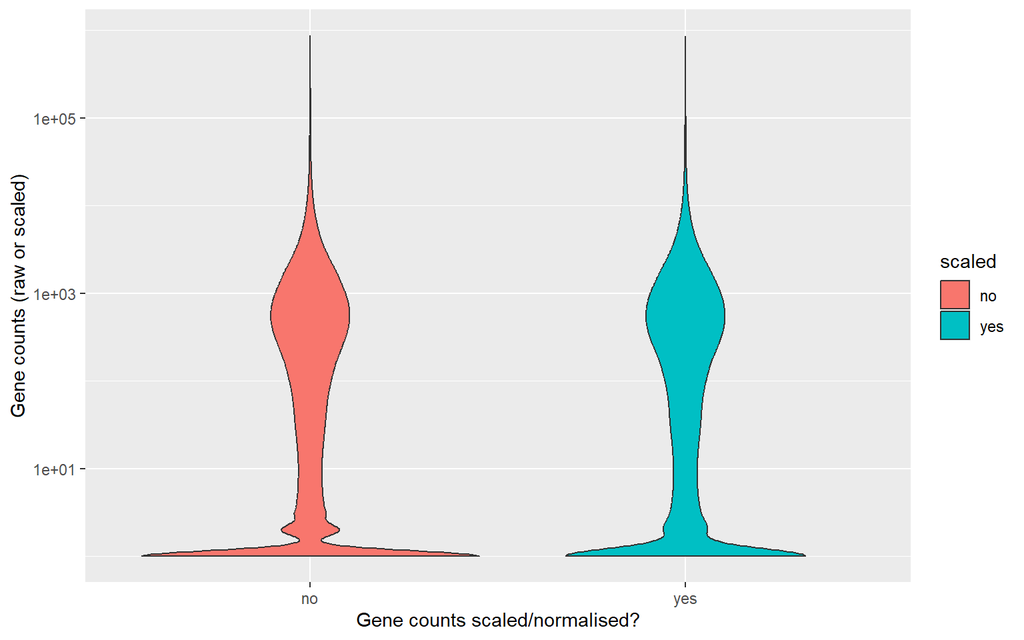

```r
long_scaled_counts =
  scaled_counts %>%
  rownames_to_column("gene") %>%
  pivot_longer(-gene, names_to = "sample", values_to = "counts") %>%
  mutate(scaled = "yes")

long_raw_counts =
  raw_counts %>%
  rownames_to_column("gene") %>%
  pivot_longer(-gene, names_to = "sample", values_to = "counts") %>%
  mutate(scaled = "no")

long_raw_and_scaled_counts = bind_rows(long_raw_counts, long_scaled_counts)

ggplot(long_raw_and_scaled_counts,
       aes(x = scaled, y = counts + 1, fill = scaled)) +
  geom_violin() +
  scale_y_log10() +
  labs(x = "Gene counts scaled/normalised?", y = "Gene counts (raw or scaled)")
```

# Heatmap (mapa cieplna)

```r
counts_normalised_only_diff_genes =
  mor_normalization(raw_counts) %>%             # normalize the counts using our custom function
  rownames_to_column("genes") %>%
  pivot_longer(- genes,
               names_to = "sample",
               values_to = "counts") %>%
  filter(genes %in% diff_genes$genes) %>%
  pivot_wider(names_from = "sample",
              values_from = "counts")  %>%
  column_to_rownames("genes")                   # the gene column is converted back to row names to create a matrix usable with pheatmap

dim(counts_normalised_only_diff_genes)          # check that you have the expected number of rows and columns
```

```
## [1] 4979   48
```

Rzeczywiście stwierdzamy, że mamy 4979 różnicujących genów (wiersze, p <0, 01) i 48 próbek (kolumny).

```r
set.seed(1)
x <- runif(7)

# Manually scaling
(x - mean(x)) / sd(x)
```

```
## [1] -1.01951259 -0.68940037 -0.06788275  0.97047346 -1.21713898  0.94007371
## [7]  1.08338753
```

```r
# With scale function
scale(x)[,1]
```

```
## [1] -1.01951259 -0.68940037 -0.06788275  0.97047346 -1.21713898  0.94007371
## [7]  1.08338753
```

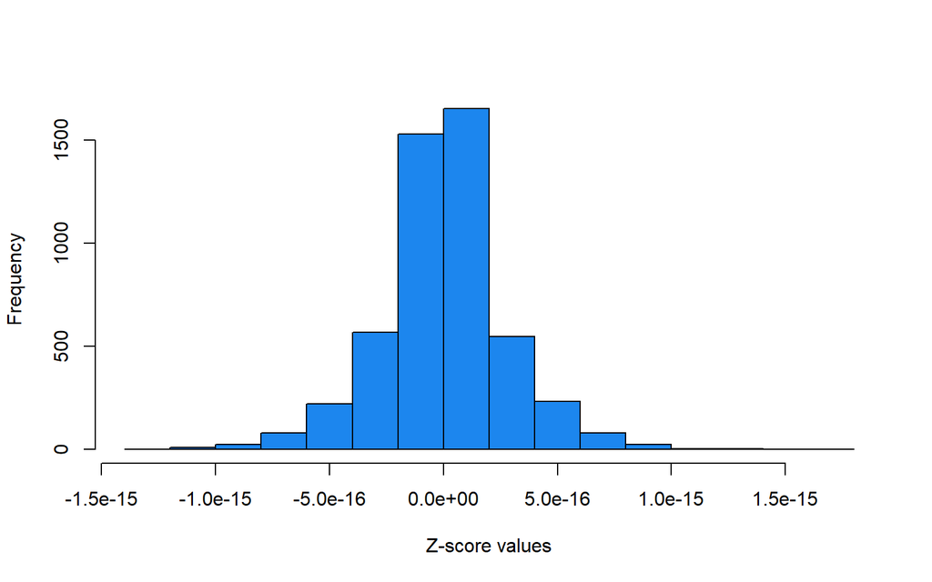

```r
counts_scaled =
  counts_normalised_only_diff_genes %>%
  t(.) %>%                              # transpose to have the genes in columns
  scale() %>%                           # scale(x, center = TRUE, scale = TRUE)
  t(.)                                  # back in original shape

# sanity check
# the majority of the values should be around zero
apply(counts_scaled, MARGIN = 1, mean) %>%                          # calculate the mean per row
  hist(., main = "", xlab = "Z-score values", col = "dodgerblue2")
```

Z-score dla każdego genu Z= (x - μ) /σ Gdzie X to indywidualna liczba genów w danej próbce, μ średnią wiersza dla tego genu we wszystkich próbkach, a σ to jego odchylenie standardowe.

Z-score to wartość statystyczna wyrażająca liczbę odchyleń standardowych wartości od średniej populacji. Wynikowy Z-score dla danego genu i próbki mówi, ile standardowych odchyleń wynikających z ekspresji genu w próbce jest oddalone od średniej ekspresji tego genu we wszystkich próbkach. Ujemne wartości Z-score oznaczają, że ekspresja danego genu jest niższa niż średnia, podczas gdy wartości dodatnie oznaczają, że ekspresja jest wyższa niż średnia.

```r
counts_scaled_filtered =
  counts_scaled %>%
  as.data.frame() %>%
  dplyr::select(row.names(xp_design_mock_vs_infected)) # keep the 8 samples

head(counts_scaled_filtered)
```

```
##            ERR1406305  ERR1406306 ERR1406307  ERR1406308 ERR1406263 ERR1406264
## AT1G03987  0.08111051 -1.44793863 -1.4367552 -1.22118803  0.5918733  1.2571858
## AT1G01030 -0.30670965 -0.06870748 -0.8326561 -1.15481563  0.1507923  3.4985846
## AT1G01070  0.41923586  2.22548081  0.7048437  0.02213018 -0.5909422 -0.9481945
## AT1G01090 -0.00634541 -0.61229814  0.3030398  0.23723593 -0.9682093 -2.9753979
## AT1G01140 -0.59349290 -0.65022509 -0.5919727 -0.81521932  1.1542905  2.9312591
## AT1G04013  0.09030415  0.12136588 -0.5822217  0.25818718  1.7809275  2.2927280
##           ERR1406265 ERR1406266
## AT1G03987  1.4186304  2.3675708
## AT1G01030  0.8385680  0.3856609
## AT1G01070 -0.1742356 -0.6123803
## AT1G01090 -1.3136586 -2.0352224
## AT1G01140  1.9642396  1.0622369
## AT1G04013  0.6519806  1.9829497
```

```r
topGenes <- head(order(diff_genes$padj),20)
```

```r
top_counts_scaled_filtered <- counts_scaled_filtered[topGenes,]
```

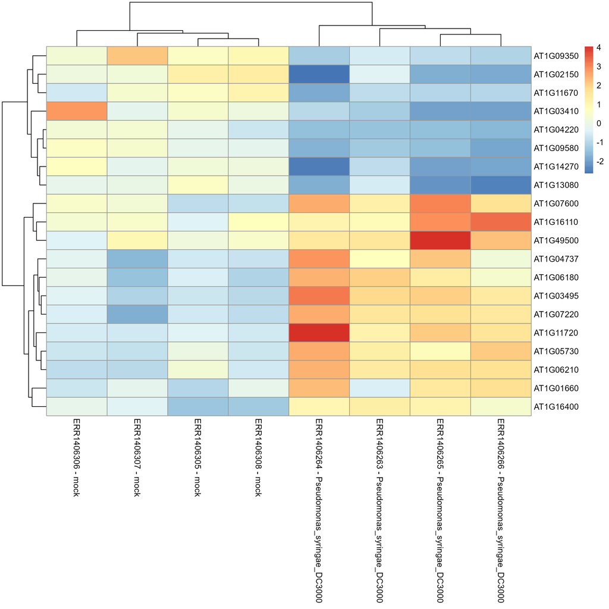

```r
# pheatmap_top_genes <-as.matrix(top_counts_scaled_filtered)
# colnames(pheatmap_top_genes) <- paste(row.names(xp_design_mock_vs_infected), xp_design_mock_vs_infected$infected, sep = " - " )
#
# heatmap <- pheatmap(pheatmap_top_genes)
# #ggsave("heatmap.png", plot = heatmap, width = 10, height = 10)
```